# PS117 CTD Data

# 1 Introduction

This script looks at the differences between the raw and calibrated CTD data from the PS117 expedition.

Written by: Elise Droste (e.droste@uea.ac.uk)

Start script: 20200424

## Data

I'm using the calibrated continuous profile data for the AWI CTD, which I retrieved from Pangaea (Rohardt et al., 2020).

- Salinity, temperature, potential temperature, oxygen, fluorescence, etc.: calibrated profile data for AWI CTD casts retrieved from Pangaea (Rohardt et al, 2020a). This data was re-formatted by Elise Droste (see `PS117_reformat_pangaea-retrieved-datafiles.ipynb`).

Note that I currently do not have access to the calibrated UCC data (neither bottle nor profile data).

## References

Boebel, O. (2019). The Expedition PS117 of the Research Vessel POLARSTERN to the Weddell Sea in 2018/2019. Berichte zur Polar-und Meeresforschung= Reports on polar and marine research, 732. https://doi.org/10.2312/BzPM_0732_2019

Rohardt, Gerd; Boebel, Olaf (2020a): Physical oceanography during POLARSTERN cruise PS117. Alfred Wegener Institute, Helmholtz Centre for Polar and Marine Research, Bremerhaven, PANGAEA, https://doi.org/10.1594/PANGAEA.910663

# 2 Packages and Data

## 2.1 Import Relevant Packages

```python
import numpy as np
import pandas as pd
import matplotlib.pyplot as plt

from pathlib import Path
import  warnings
warnings.filterwarnings('ignore')

import os
from pathlib import PurePosixPath

from os.path import isfile
import glob
import datetime

from _plotly_future_ import v4_subplots
import plotly
import plotly.graph_objs as go
from plotly.graph_objs import Scatter
plotly.offline.init_notebook_mode(connected=True)

import matplotlib.dates as mdates
import matplotlib
import mpl_toolkits.axisartist as axisartist
```

## 2.2 Set Directory Paths

```python
fig_dir = "/Users/elisedroste/ED_PhD/ED_PhD_PS117/ED_PhD_PS117_output_figures/raw_vs_cal_awictd/"
```

## 2.3 Read Data

### 2.3.1 Read Calibrated AWI CTD Data PS117

This data is retrieved from Pangaea (Rohard et al., 2020a) and has been reformatted by Elise Droste.

```python
df_prof_cal = pd.read_csv(Path("/Users/elisedroste/ED_PhD/ED_PhD_PS117/ED_PhD_PS117_output_datafiles/PS117_AWI_pangaea_data_ED")/"PS117_awiprofilefile_calreform_ret20200323_20200323.csv")
```

Select the tidal cycle data only

```python
# Select only the tidal stations
df_tidal_awi_cal = df_prof_cal[df_prof_cal["Event"].str.contains("PS117_41")].reset_index(drop=True)

# Convert DateTime to datetime type
df_tidal_awi_cal["DateTime"] = pd.to_datetime(df_tidal_awi_cal["DateTime"])

# Change some of the column names
df_tidal_awi_cal.columns = ['Event', 'DateTime', 'Latitude', 'Longitude', 'Elevation',
                         'Depth', 'Pressdbar', 'TempdegC', 'Cond', 'Sal',
                         'TpotdegC', 'Sigma-theta', 'O2umoll', 'O2sat',
                         'Attenuation', 'Fluorometer', 'NOBS']
```

```python
# The data frame contains the Event label but does not have a separate column for station and cast
# Adding them here
df_stationcast = df_tidal_awi_cal["Event"].str.split("_", expand = True)[1].str.split("-", expand = True)

df_tidal_awi_cal["Station"] = df_stationcast[0].astype(int)
df_tidal_awi_cal["Cast"] = df_stationcast[1].astype(int)
```

### 2.3.2 Read Raw AWI CTD Data PS117

Raw AWI CTD data has been converted from matlab files into csv format by Elise Droste on 25 January 2019, using the script `mat_to_csv_ctd_profiles.ipynb`.

2.3.2.1 Find the Relevant raw profiles and merge

The raw CTD profile data are saved in separate csv files in the directory shown below. Find the profiles for the tidal cycle and merge them (for future use).

Only run the next cell if you want to re-select the tidal data, otherwise just import from last time (see the cell below).

```python
raw_ctd_awi_dir = Path("/Users/elisedroste/ED_PhD/ED_PhD_PS117/ED_PhD_PS117_output_datafiles/PS117_AWICTD_profiles_csv-files")

# There are 4 casts done with the AWI CTD for the tidal cycle experiment
# (I chose to do it manually here because it's just 4 files)
cast01 = "PS117_041_01_ctd_profile.csv"
cast06 = "PS117_041_06_ctd_profile.csv"
cast09 = "PS117_041_09_ctd_profile.csv"
cast12 = "PS117_041_12_ctd_profile.csv"

# Put them into a list
cast_list = [cast01, cast06, cast09, cast12]

# Loop through the list with the file names (one per cast)
for i in np.arange(len(cast_list)):
    if i == 0:
        # Read the file
        df_tidal_awi_raw = pd.read_csv(raw_ctd_awi_dir/cast_list[i])
        # Find the station and cast based on the file name
        station = int(cast_list[i].split("_")[1])
        cast = int(cast_list[i].split("_")[2])
        # Create new columns that contain the station and cast name (to be able to identify them later)
        df_tidal_awi_raw["Station"] = station
        df_tidal_awi_raw["Cast"] = cast
    else:
        # Same thing done as above
        df1 = pd.read_csv(raw_ctd_awi_dir/cast_list[i])
        station = int(cast_list[i].split("_")[1])
        cast = int(cast_list[i].split("_")[2])
        df1["Station"] = station
        df1["Cast"] = cast
        # Data is added to the data frame
        df_tidal_awi_raw = pd.concat([df_tidal_awi_raw, df1], ignore_index = True)
        df_tidal_awi_raw.drop("Unnamed: 0", axis = 1, inplace = True)


# Save the data frame for future use
tidal_data_dir = "/Users/elisedroste/ED_PhD/ED_PhD_PS117/ED_PhD_PS117_output_datafiles/PS117_TidalCycle/"
tidal_awi_raw_file = "PS117_tidal_awictd_prof_raw_" + datetime.date.today().strftime("%Y%m%d") + ".csv"

df_tidal_awi_raw.to_csv(tidal_data_dir + tidal_awi_raw_file, index = False)
```

Import here:

```python
df_tidal_awi_raw = pd.read_csv(Path("/Users/elisedroste/ED_PhD/ED_PhD_PS117/ED_PhD_PS117_output_datafiles/PS117_TidalCycle") / "PS117_tidal_awictd_prof_raw_20200424.csv")
```

# 3 Plot Raw vs Calibrated AWI CTD Tidal Data

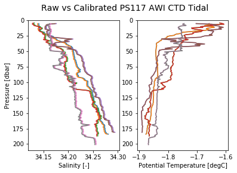

```python
fig = plt.figure()
ax1 = fig.add_subplot(121)
ax2 = fig.add_subplot(122)

cast_numbers = [1, 6, 9, 12]

for i in cast_numbers:
    raw_p = df_tidal_awi_raw["PRES"][df_tidal_awi_raw["Cast"] == i]
    raw_s = df_tidal_awi_raw["SALT"][df_tidal_awi_raw["Cast"] == i]
    raw_tpot = df_tidal_awi_raw["PTEM"][df_tidal_awi_raw["Cast"] == i]

    cal_p = df_tidal_awi_cal["Pressdbar"][df_tidal_awi_cal["Cast"] == i]
    cal_s = df_tidal_awi_cal["Sal"][df_tidal_awi_cal["Cast"] == i]
    cal_tpot = df_tidal_awi_cal["TpotdegC"][df_tidal_awi_cal["Cast"] == i]

    ax1.plot(raw_s, raw_p)
    ax1.plot(cal_s, cal_p)

    ax2.plot(raw_tpot, raw_p)
    ax2.plot(cal_tpot, cal_p)

ax1.set_ylabel("Pressure [dbar]")
ax1.set_xlabel("Salinity [-]")
ax2.set_xlabel("Potential Temperature [degC]")

ax1.set_ylim(210, 0)
ax2.set_ylim(210, 0)

fig.text(0.5, 0.95, "Raw vs Calibrated PS117 AWI CTD Tidal", ha = "center", va = "center", fontsize = 14)
```

There seems to be very little difference between the calibrated and uncalibrated AWI CTD data for these four stations/casts.

I didn't expect a big difference in the first place, but comparisons between my tidal graphs for salinity and potential temperature suggested that there were significant differences, which is why I wanted to double check it here.

I want to check it with an interactive plot (done next).

```python
from plotly.subplots import make_subplots
```

```python
# fig_rawvscal = go.Figure()
fig_rawvscal = make_subplots(rows = 1, cols = 2)

cast_numbers = [1, 6, 9, 12]
cast_colour_dict = {1: "olive", 6: "darkblue", 9: "salmon", 12: "indigo"}

for i in cast_numbers:
    raw_p = df_tidal_awi_raw["PRES"][df_tidal_awi_raw["Cast"] == i]
    raw_s = df_tidal_awi_raw["SALT"][df_tidal_awi_raw["Cast"] == i]
    raw_tpot = df_tidal_awi_raw["PTEM"][df_tidal_awi_raw["Cast"] == i]
    raw_cast = df_tidal_awi_raw["Cast"][df_tidal_awi_raw["Cast"] == i]

    cal_p = df_tidal_awi_cal["Pressdbar"][df_tidal_awi_cal["Cast"] == i]
    cal_s = df_tidal_awi_cal["Sal"][df_tidal_awi_cal["Cast"] == i]
    cal_tpot = df_tidal_awi_cal["TpotdegC"][df_tidal_awi_cal["Cast"] == i]
    cal_cast = df_tidal_awi_cal["Cast"][df_tidal_awi_cal["Cast"] == i]


    fig_rawvscal.add_trace(go.Scatter(
        x = raw_s.values,
        y = raw_p.values,
        hovertext = "Raw "+str(i),
        mode = "markers",
        marker_symbol = "circle",
        name = "Raw "+str(i),
        opacity = 0.5,
        marker = dict(color = cast_colour_dict[i],
                      size = 12,
                      line = dict(color = "DarkSlateGrey"))
                                        ),
        row = 1, col = 1)

    fig_rawvscal.add_trace(go.Scatter(
        x = cal_s.values,
        y = cal_p.values,
        hovertext = "Cal "+str(i),
        mode = "markers",
        marker_symbol = "circle",
        opacity = 0.9,
        name = "Calibrated " + str(i),
        marker = dict(color = cast_colour_dict[i],
                      size = 8,
                     line = dict(width = 1))
                                        ),
        row = 1, col = 1)

    fig_rawvscal.add_trace(go.Scatter(
        x = raw_tpot.values,
        y = raw_p.values,
        hovertext = "Raw "+str(i),
        mode = "markers",
        marker_symbol = "circle",
        name = "Raw "+str(i),
        opacity = 0.5,
        marker = dict(color = cast_colour_dict[i],
                      size = 12,
                      line = dict(color = "DarkSlateGrey"))
                                        ),
        row = 1, col = 2)

    fig_rawvscal.add_trace(go.Scatter(
        x = cal_tpot.values,
        y = cal_p.values,
        hovertext = "Cal "+str(i),
        mode = "markers",
        marker_symbol = "circle",
        opacity = 0.9,
        name = "Calibrated " + str(i),
        marker = dict(color = cast_colour_dict[i],
                      size = 8,
                     line = dict(width = 1))
                                        ),
        row = 1, col = 2)


fig_rawvscal.update_xaxes(title_text = "Salinity [-]", row = 1, col = 1)
fig_rawvscal.update_yaxes(title_text = "Pressure [dbar]", range = [210,0], row = 1, col = 1)

fig_rawvscal.update_xaxes(title_text = "Potential Temperature [degC]", row = 1, col = 2)
fig_rawvscal.update_yaxes(title_text = "Pressure [dbar]", range = [210,0], row = 1, col = 2)


fig_rawvscal.layout.update(hovermode="closest", title = "PS117 Raw vs Cal Tidal AWI CTD", height = 600, width = 800, showlegend = False)#legend = dict(y=0.05, x = 0.05, bordercolor = "DarkSlateGrey", borderwidth = 1.1))


fig_rawvscal.show()
```

[interactive chart not shown]

Consistent differences beween raw and calibrated data, but does not explain the differences I see between my data and that in the cruise report for the tidal cycle...